# Coding Exercise

Key

October 2nd, 2018

Before getting started, place this file in the project folder we started during class. Click the “knit” button near the top of RStudio. You should get an HTML output. If not raise your hand and I will come help you. Once you have successfully knit the file, you can proceed with the rest of the lab.

## Scenario

A local school district is interested in how their third grade students are performing on an end-of-year tests. There have been major efforts to reduce achievement disaprities. For this particular investigation, they are primarily interested in how large the achievement gaps remain on the end of year tests. A secondary question, however, relates to how large student gains in reading are from the fall to the spring, while controlling for specific student demographics.

1. Place the “benchmarks.xlsx” dataset (from Canvas) into a folder in your RStudio Project called “data”. Using the code chunk below, write the appropriate code to load the data into R and store it in an object, `d`. As a reminder, you will need two packages to import the data: {here} and {rio}. Look back to Lab 2 if you are having trouble.

```r
library(rio)
library(here)
d <- import(here("data", "benchmarks.xlsx"),
            setclass = "tbl_df")
```

2. Use a few functions to explore the data (e.g., show the first few rows, show the structure, dimensions, etc.)

```r
head(d)
```

```
## # A tibble: 6 x 7
##      sid sped     ethnicity  frl   ell     rdg_fall rdg_spr
##    <dbl> <chr>    <chr>      <chr> <chr>      <dbl>   <dbl>
## 1 409687 Non-Sped Hispanic   FRL   Active       181     194
## 2 409847 Sped     Black      FRL   Non-ELL      166     159
## 3 491527 Sped     White      FRL   Non-ELL      216     198
## 4 500147 Non-Sped Native Am. FRL   Non-ELL      203     204
## 5 501027 Non-Sped Hispanic   FRL   Active       198     173
## 6 501147 Non-Sped Hispanic   FRL   Active       188     173
```

```r
str(d)
```

```
## Classes 'tbl_df', 'tbl' and 'data.frame':    174 obs. of  7 variables:
##  $ sid      : num  409687 409847 491527 500147 501027 ...
##  $ sped     : chr  "Non-Sped" "Sped" "Sped" "Non-Sped" ...
##  $ ethnicity: chr  "Hispanic" "Black" "White" "Native Am." ...
##  $ frl      : chr  "FRL" "FRL" "FRL" "FRL" ...
##  $ ell      : chr  "Active" "Non-ELL" "Non-ELL" "Non-ELL" ...
##  $ rdg_fall : num  181 166 216 203 198 188 202 182 194 170 ...
##  $ rdg_spr  : num  194 159 198 204 173 173 200 206 191 185 ...
```

# Research Question 1

> What are the average differences on the spring reading measure among students receiving English language learner services by ethnicity?
3. Modify the code chunk below to define all categorical variables as factors.

```r
library(tidyverse)
d <- d %>%
  mutate(sped = factor(sped),
         ethnicity = factor(ethnicity),
         frl = factor(frl),
         ell = factor(ell))
```

4. Write the code to display boxplots of students’ spring reading scores by ELL status and ethnicity. Hint: You will need to either use `facet_wrap` or add an additional aesthetic (`fill` or `color`) to the boxplot layer.

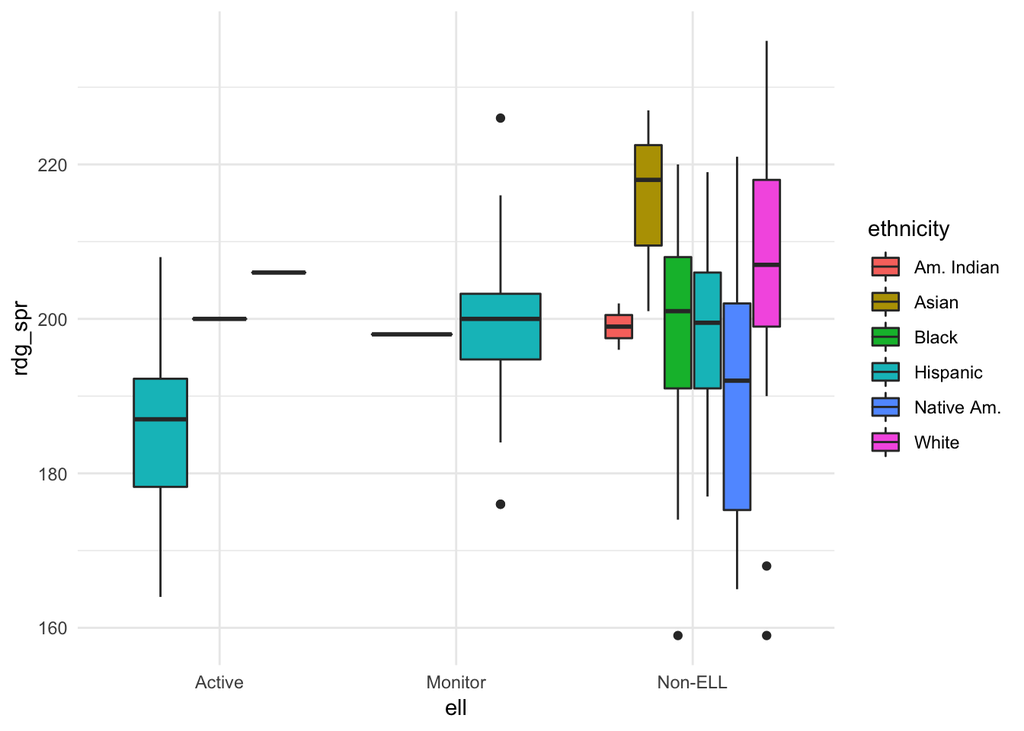

```r
theme_set(theme_minimal())
ggplot(d, aes(ell, rdg_spr)) +
  geom_boxplot(aes(fill = ethnicity))
```

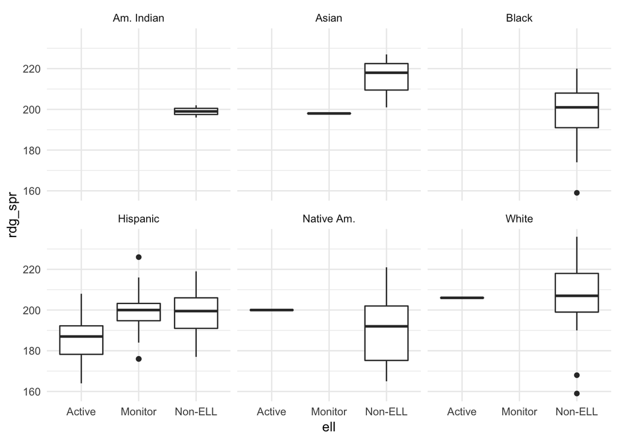

```r
ggplot(d, aes(ell, rdg_spr)) +
  geom_boxplot() +
  facet_wrap(~ethnicity)
```

4. Fit the corresponding model

$$rdg_{spr} = b_0 + b_1(ELL_i) + b_2(Ethnicity_i) + e$$

```r
m1a <- lm(rdg_spr ~ ell + ethnicity, d)
arm::display(m1a, detail = TRUE)
```

```
## lm(formula = rdg_spr ~ ell + ethnicity, data = d)
##                     coef.est coef.se t value Pr(>|t|)
## (Intercept)         187.91     7.96   23.61    0.00
## ellMonitor           11.71     3.08    3.80    0.00
## ellNon-ELL           11.09     3.05    3.64    0.00
## ethnicityAsian       11.85     9.75    1.21    0.23
## ethnicityBlack       -1.81     7.86   -0.23    0.82
## ethnicityHispanic    -0.74     7.67   -0.10    0.92
## ethnicityNative Am.  -5.27     8.80   -0.60    0.55
## ethnicityWhite        8.34     7.62    1.10    0.27
## ---
## n = 174, k = 8
## residual sd = 12.73, R-Squared = 0.23
```

Provide a substantive interpretation of the model below, making sure to interpret the intercept and at least one slope from each group, as well as the model $R^2$.

#### Substantive Interpretation

5. Modify the code below to change the reference group to Students identifying as “White” who did not receive English language services. Remember, you’ll need use the `relevel` function.

```r
d <- d %>%
  mutate(ell = relevel(factor(ell), ref = "Non-ELL"),
         ethnicity = relevel(factor(ethnicity), ref = "White"))
```

6. Re-fit the model

```r
m1b <- lm(rdg_spr ~ ell + ethnicity, d)
arm::display(m1b, detail = TRUE)
```

```
## lm(formula = rdg_spr ~ ell + ethnicity, data = d)
##                     coef.est coef.se t value Pr(>|t|)
## (Intercept)         207.34     1.99  104.19    0.00
## ellActive           -11.09     3.05   -3.64    0.00
## ellMonitor            0.62     2.99    0.21    0.84
## ethnicityAm. Indian  -8.34     7.62   -1.10    0.27
## ethnicityAsian        3.50     6.71    0.52    0.60
## ethnicityBlack      -10.15     3.42   -2.97    0.00
## ethnicityHispanic    -9.08     2.91   -3.12    0.00
## ethnicityNative Am. -13.62     5.22   -2.61    0.01
## ---
## n = 174, k = 8
## residual sd = 12.73, R-Squared = 0.23
```

Has the variance accounted for by the model changed? Why?

Provide a brief substantive interpretation of the re-fit model.

#### Substantive Interpretation

The variance accounted for by the model is equivalent because the same groups are represented in the analysis. The coefficients themselves have changed because they are in reference to a different group of students. Rather than representing the difference between the corresponding group and students coded as American Indian, who were actively receiving ELL services, the coefficients now represent the differences between the corresponding group and students coded as White who never recieved ELL services. This group scored, on average, 207.34 points on the spring outcome. Controlling for ethnicity, students actively receiving ELL services scored, on average, 11.09 lower than this group. Similarly, controlling for ELL status, students coded as Black scored 10.15 points below this reference group, on average.

# Research Question 2

> What is the average reading score gain from fall to spring, controlling for ethnicity?
7. Write code using ggplot to visualize the relation between the fall and spring reading scores, using spring as the outcome. Display the linear regression line.

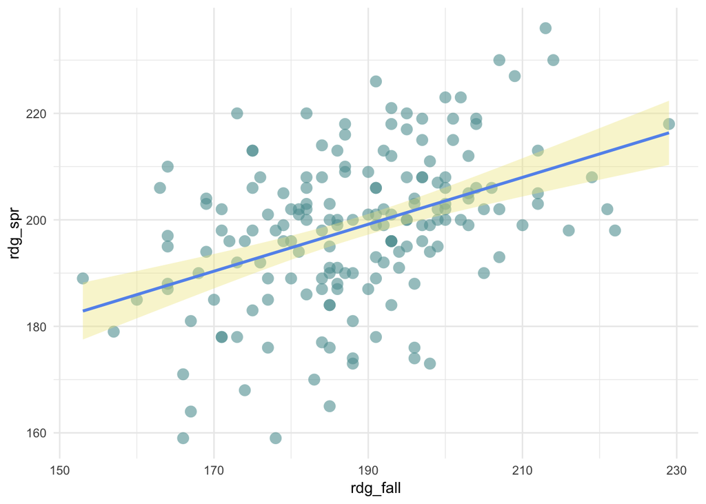

```r
ggplot(d, aes(rdg_fall, rdg_spr)) +
  geom_point(alpha = 0.6,
             stroke = 0,
             size = 4,
             color = "cadetblue") +
  geom_smooth(method = "lm",
              color = "cornflowerblue",
              fill = "khaki")
```

Copy and paste the code you wrote above and paste it in the chunk below. Add an additional aesthetic to the smoothed layer to display separate lines by English language learner status (ell column).

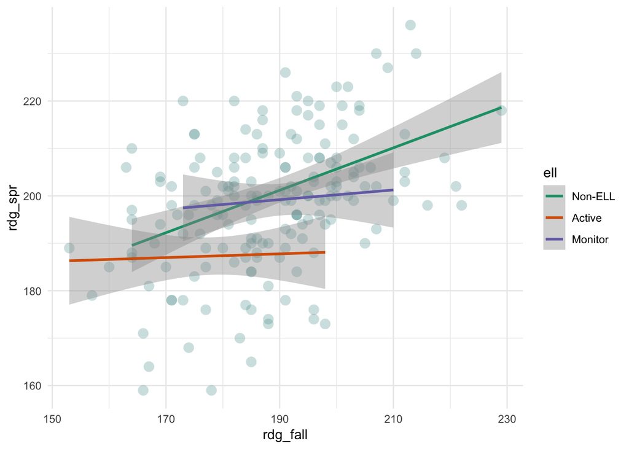

```r
ggplot(d, aes(rdg_fall, rdg_spr)) +
  geom_point(alpha = 0.3,
             stroke = 0,
             size = 4,
             color = "cadetblue") +
  geom_smooth(method = "lm",
              aes(color = ell)) +
  scale_color_brewer(palette = "Dark2")
```

Provide some substantive interpretation of the above plot.

#### Substantive Interpretation

The above plot appears to indicate that the relation between the fall and spring scores depended upon ELL status, with the relation being markedly steeper for students who never received ELL services. However, the intercepts for the three lines are also noticeably different.

8. Fill in the code chunk below to fit the following model to address the research question.

$$rdg_{spr_i} = b_0 + b_1(rdg_{fall_i}) + b_2(Ethnicity_i) + e$$

```r
m2a <- lm(rdg_spr ~ rdg_fall + ethnicity, d)
arm::display(m2a, detail = TRUE)
```

```
## lm(formula = rdg_spr ~ rdg_fall + ethnicity, data = d)
##                     coef.est coef.se t value Pr(>|t|)
## (Intercept)         135.73    14.38    9.44    0.00
## rdg_fall              0.36     0.07    5.01    0.00
## ethnicityAm. Indian  -9.11     7.46   -1.22    0.22
## ethnicityAsian        4.74     6.53    0.73    0.47
## ethnicityBlack       -5.53     3.46   -1.60    0.11
## ethnicityHispanic    -8.61     2.41   -3.57    0.00
## ethnicityNative Am. -11.26     5.15   -2.19    0.03
## ---
## n = 174, k = 7
## residual sd = 12.47, R-Squared = 0.26
```

Display a summary of the model. Put your interpretation below, specifically stating what the coefficients (intercept and slope) represent. Does this model correspond to the plot you’ve displayed above? Why or why not?

#### Substantive Interpretation

9. Modify the code chunk below to change the contrasts for ethnicity to effect coding .

```r
contrasts(d$ethnicity) <- contr.sum(6)
```

10. Refit the model

```r
m2b <- lm(rdg_spr ~ rdg_fall + ethnicity, d)
arm::display(m2b, detail = TRUE)
```

```
## lm(formula = rdg_spr ~ rdg_fall + ethnicity, data = d)
##             coef.est coef.se t value Pr(>|t|)
## (Intercept) 130.76    14.00    9.34    0.00
## rdg_fall      0.36     0.07    5.01    0.00
## ethnicity1    4.96     2.48    2.00    0.05
## ethnicity2   -4.15     6.19   -0.67    0.50
## ethnicity3    9.71     5.43    1.79    0.08
## ethnicity4   -0.57     2.94   -0.19    0.85
## ethnicity5   -3.65     2.15   -1.69    0.09
## ---
## n = 174, k = 7
## residual sd = 12.47, R-Squared = 0.26
```

Interpret the model with the effect-coded ethnicity variable. Again note why $R^2$ was or was not changed, state what the intercept represents, and interpret the coefficients substantively.